# Cell Key Method for count data in grid cells

Martin Möhler

24.07.2023

The following vignettes are useful: [ptable](https://cran.r-project.org/web/packages/ptable/vignettes/introduction.html), [cellKey](https://cran.r-project.org/web/packages/cellKey/vignettes/introduction.html), [sdcSpatial](https://cran.r-project.org/web/packages/sdcSpatial/index.html)

The following packages are needed:

```r
library(ptable)     # create ptable for CKM
library(sdcSpatial) # SDC for grid data
library(raster)     # grid data handling
library(dplyr)      # convenience
library(data.table) # convenience
library(viridis)    # plotting
```

## Prepare example microdata

As an example, raw population counts from the Census 2011 are treated with the Cell Key Method (CKM). In a first step, we download the aggregates from [here](https://www.zensus2011.de/DE/Home/Aktuelles/DemografischeGrunddaten.html?nn=559100#Gitter). ‘“Bevölkerung im 100 Meter-Gitter” im CSV-Format’. The grid size is 100m by 100m.

We reverse-transform this data back into microdata, which we will use as our example data set. To speed everything up, we only look at a 50km by 50km area (i.e. 500 by 500 grid cells).

```r
pop <- fread("data/Zensus_Bevoelkerung_100m-Gitter.csv")

# select 50km x 50km chunk
pop <- filter(pop, Einwohner > 0 &
                x_mp_100m > 4125000 & x_mp_100m < 4175000 &
                y_mp_100m > 3010000 & y_mp_100m < 3060000)

# to microdata
pop <- pop[, .(1:Einwohner, x_mp_100m, y_mp_100m), by = .(Gitter_ID_100m)] %>%
  select(-V1)

pop$person_id <- 1:nrow(pop)

head(pop, 10)
```

```
##       Gitter_ID_100m x_mp_100m y_mp_100m person_id
##  1: 100mN30100E41257   4125750   3010050         1
##  2: 100mN30100E41257   4125750   3010050         2
##  3: 100mN30100E41257   4125750   3010050         3
##  4: 100mN30100E41258   4125850   3010050         4
##  5: 100mN30100E41258   4125850   3010050         5
##  6: 100mN30100E41258   4125850   3010050         6
##  7: 100mN30100E41258   4125850   3010050         7
##  8: 100mN30100E41259   4125950   3010050         8
##  9: 100mN30100E41259   4125950   3010050         9
## 10: 100mN30100E41259   4125950   3010050        10
```

## Set up for CKM

As our first step, we draw the record keys (one per entry in the microdata).

```r
set.seed(20230724)
pop$rkey <- round(runif(nrow(pop), 0, 1), 7)
```

Next, we need a perturbation table for count data. These are made using the ptable package. The specific parameters used here are taken from one of the examples in the package vignette.

```r
ptab <- create_cnt_ptable(D = 5, V = 3, js = 2, mono = TRUE, )
ptab <- modify_cnt_ptable(ptab, threshold = 0.1, seed = 1234)
```

```
## There are 16 consecutive intervals with identical noise. You can try another
##           'seed' or proceed. At least, check whether the modified ptable has
##           sufficiently rearranged sub-intervals.
```

```
##
##  NOTE for Tau-Argus:
##           Please use a new Tau-Argus Release (>= 4.2.3).
```

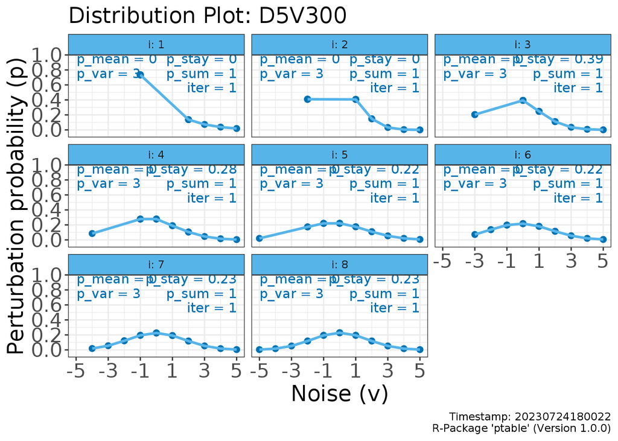

```r
ptable::plot(ptab, type = "d") # noise distributions for given i
```

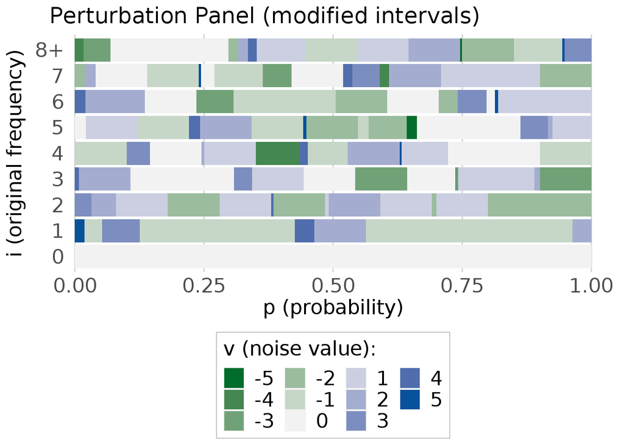

```r
ptable::plot(ptab, type = "p") # perturbation panel
```

In order to apply CKM to grid data, we define a number of functions. Firstly, we extend the sdc_raster object from the sdcSpatial package to store cell keys together with its other aggregates. Secondly, we include a lookup function, that gives us for each combination of aggregate cell value and cell key the corresponding additive noise from the ptable. Finally, our third function calls the lookup function for each cell aggregate, adds the proper noise and returns the perturbed raster object.

```r
##### Create an sdc_raster object that includes cell keys #################### #
# x        : SpatialPointsDataFrame, sf (point data), or 2-column matrix of
#            coordinates
# variable : name of field in sp or sf; when using coordinates a numeric of
#            length x
# rkey     : name of field in sp or sf that contains record keys; when using
#            coordinates a numeric vector of record keys with length x
############################################################################## #

sdc_raster_new <- function(x, variable, rkey, ...) {

  # default sdc_raster call
  sr <- sdc_raster(x, variable, ...)

  # cell keys from record keys
  if(is.numeric(rkey)) {
    le_rkey <- nchar(rkey[1]) - 2
    } else { le_rkey <- nchar(x[[rkey]][1]) - 2 }

  ck <- raster::rasterize(x, sr$value, fun = sum, field = rkey)
  ck <- round(ck - floor(ck), le_rkey)
  sr$value$ckeys <- ck
  sr
}


###### Look up the perturbed value by cell key from a pTable ################# #
# x_ck : length-2 vector c(cell count, cell key) for one table cell
# pt   : pTable from a ptable object
############################################################################## #

get_perturbation_value <- function(x_ck, pt) {

  if(is.na(x_ck[1])) {
    NA
  } else {
    max_x <- max(pt$i)
    pt$v[pt$i == min(max_x, x_ck[1]) & data.table::between(x_ck[2], pt$p_int_lb, pt$p_int_ub)]
  }
}


##### Perturb cell values in a raster map using CKM ########################## #
# x    : an sdc_raster object
# ptab : a ptable object
############################################################################## #

protect_ckm <- function(x, ptab) {

  r <- x$value

  # extract values
  x_ck <- cbind(raster::getValues(r[["count"]]),
                raster::getValues(r[["ckeys"]]))

  # look up noise by cell key
  v <- apply(x_ck, 1, get_perturbation_value, pt = ptab@pTable)
  # perturb values with noise
  raster::values(r[["count"]]) <- raster::values(r[["count"]]) + v

  x$value <- r
  x
}
```

Note: For this short demonstration, the functions are only set up to perturb count data.

## Apply CKM

First we create the raster to which we will aggregate the microdata. The resolution of the raster is equal to the cell width. Then we call our modified sdc_raster function (depending on the number of entries in the microdata, this may take a while).

```r
r <- raster(xmn = min(pop$x_mp_100m) - 50, xmx = max(pop$x_mp_100m) + 50,
            ymn = min(pop$y_mp_100m) - 50, ymx = max(pop$y_mp_100m) + 50,
            resolution = 100, crs = CRS("+init=epsg:3035"))

pop_ras <- sdc_raster_new(x = pop[, c("x_mp_100m", "y_mp_100m")],
                          r = r, variable = 1,
                          max_risk = 1, min_count = 10,
                          rkey = pop$rkey)
pop_ras$value[["ckeys"]]
```

```
## class      : RasterLayer
## dimensions : 500, 500, 250000  (nrow, ncol, ncell)
## resolution : 100, 100  (x, y)
## extent     : 4125000, 4175000, 3010000, 3060000  (xmin, xmax, ymin, ymax)
## crs        : +init=epsg:3035 +proj=laea +lat_0=52 +lon_0=10 +x_0=4321000 +y_0=3210000 +ellps=GRS80 +towgs84=0,0,0,0,0,0,0 +units=m +no_defs
## source     : memory
## names      : ckeys
## values     : 9.9e-06, 0.999984  (min, max)
```

Besides the usual sdc_raster layers, this one now also has a layer of cell keys on the interval $[0 \,,1]$. This allows us to call our CKM function to create perturbed raster data:

```r
pop_ras_ckm <- protect_ckm(pop_ras, ptab = ptab)
```

We may now look at the outcome.

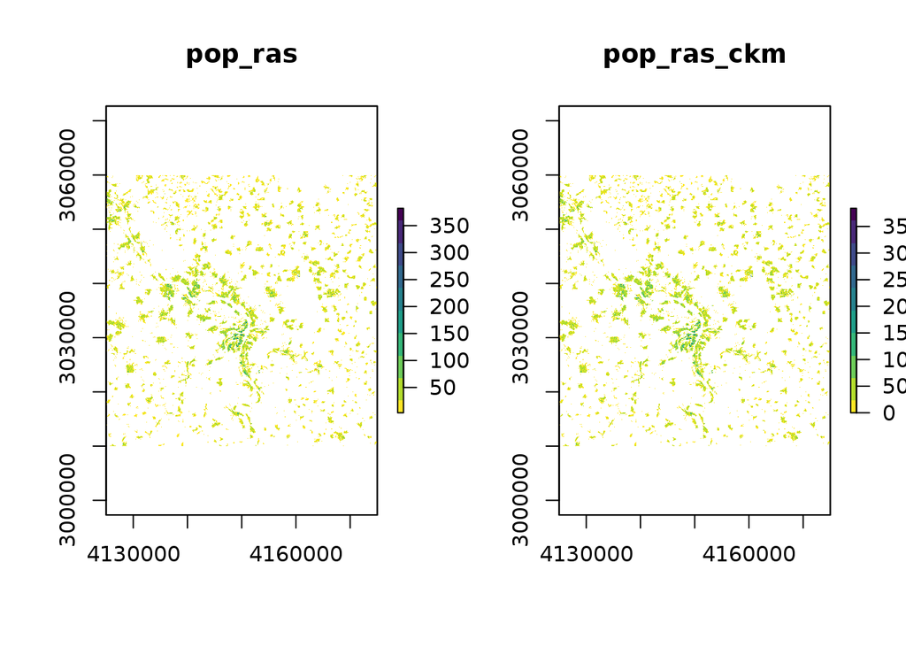

```r
pal <- rev(viridis(10))

par(mfrow = c(1, 2))
plot(pop_ras, "count",     col = pal, sensitive = FALSE)
plot(pop_ras_ckm, "count", col = pal, sensitive = FALSE)
```

```r
par(mfrow = c(1, 1))
```

## Inspect results

Using the raster package functionality, we can look at the cell-by-cell difference between the unperturbed and the perturbed raster.

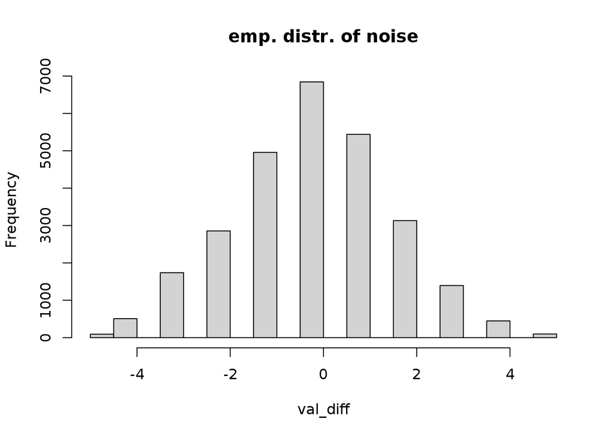

```r
# get cell-level difference perturbed vs. unperturbed
ras_diff <- pop_ras_ckm$value$count - pop_ras$value$count

val_orig <- getValues(pop_ras$value$count)     # unperturbed values
val_pert <- getValues(pop_ras_ckm$value$count) # perturbed values
val_diff <- getValues(ras_diff)                # CKM noise values

# NAs stay NAs (no false positives)
val_orig <- val_orig[!is.na(val_orig)]
val_pert <- val_pert[!is.na(val_pert)]
val_diff <- val_diff[!is.na(val_diff)]

# distribution of noise values
hist(val_diff, main = "emp. distr. of noise")
```

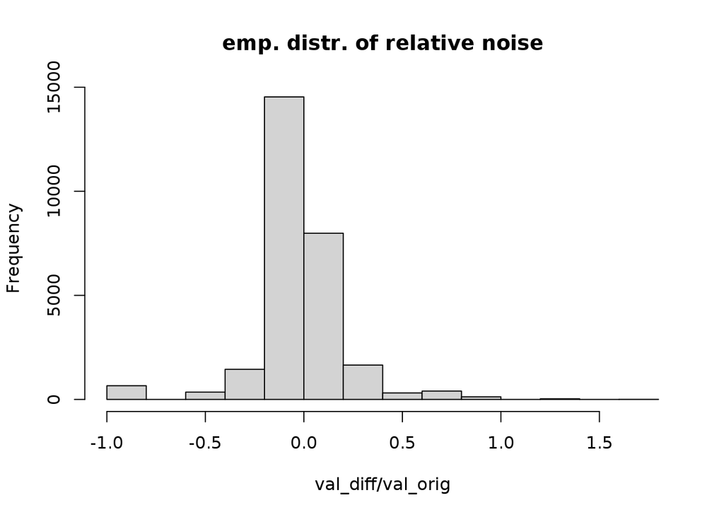

```r
hist(val_diff / val_orig, main = "emp. distr. of relative noise")
```

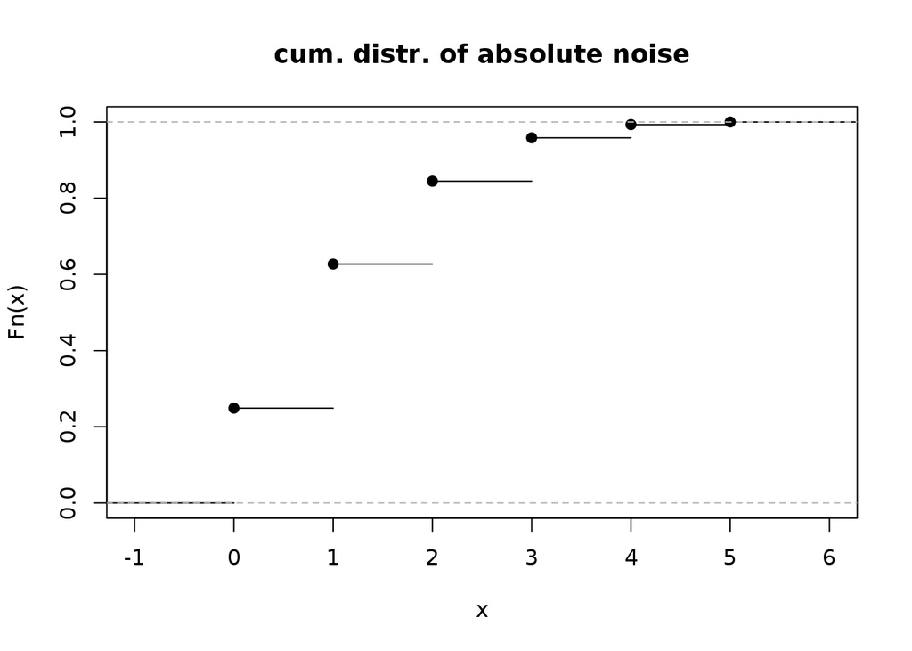

```r
plot(ecdf(abs(val_diff)), main = "cum. distr. of absolute noise")
```

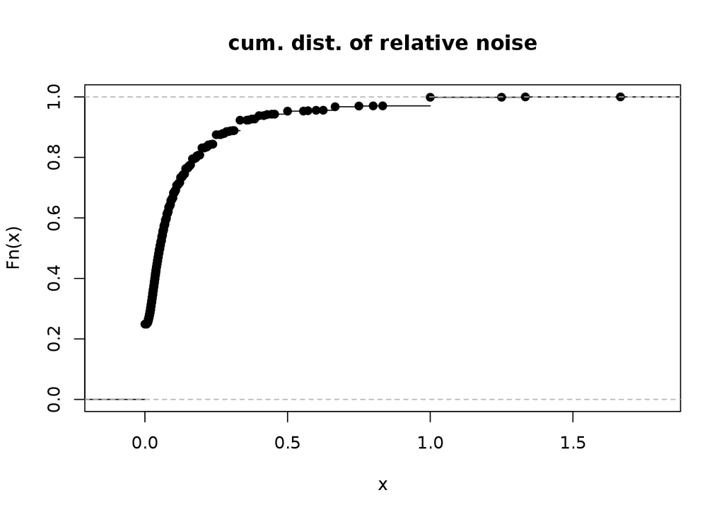

```r
plot(ecdf(abs(val_diff / val_orig)), main = "cum. dist. of relative noise")
```

[Note: While, strictly speaking, the distribution of additive noise depends on the size of the original count (see the different perturbation PDFs above), this holds only until the transition matrix has reached symmetry (here: with i = 8). That means for counts 8 and above the CKM noise is i.i.d. and can be treated as Berkson error. This should allow, in principle, to easily apply calibration techniques if desired.]

```r
# some quality indicators
paste("absolute difference in population:",
      sum(val_diff))
```

```
## [1] "absolute difference in population: -203"
```

```r
paste("relative difference in population (%):",
      round((sum(val_diff) / sum(val_orig)) * 100, 4))
```

```
## [1] "relative difference in population (%): -0.0291"
```

```r
paste("number of false zero cells:",
      sum(val_orig != 0 & val_pert == 0))
```

```
## [1] "number of false zero cells: 658"
```

```r
paste("share of false zero cells (%):",
      (sum(val_orig != 0 & val_pert == 0) / (nrow(ras_diff) * ncol(ras_diff))) * 100)
```

```
## [1] "share of false zero cells (%): 0.2632"
```

We can further use the original values, perturbed values and their difference to calculate any desired distance metric. For example:

```r
dist_metrics <- c(mean(val_diff^2),
                  mean((val_diff / val_orig)^2),
                  sqrt(mean(val_diff^2)),
                  sqrt(mean((val_diff / val_orig)^2)))
names(dist_metrics) <- c("MSE", "MSE (rel.)", "RMSE", "RMSE (rel.)")
dist_metrics
```

```
##         MSE  MSE (rel.)        RMSE RMSE (rel.)
##  2.99938186  0.05665076  1.73187236  0.23801421
```

Typically, we will be interested also in the spatial distribution of errors. Here, we do two simple tests: Firstly, we check the Moran’s I statistic for the CKM noise. As all grid cells are perturbed independently, there should be no noticeable spatial autocorrelation in the noise. Secondly, we check how the spatial autocorrelation present in the original data is impacted by CKM. We compare the Moran’s I statistic before and after perturbation.

```r
# spatial weights matrix for Moran statistic
w_queen <- matrix(c(1, 1, 1,
                    1, 0, 1,
                    1, 1, 1), ncol = 3, nrow = 3)

moran_diff <- raster::Moran(ras_diff, w = w_queen)

paste("Moran's I of CKM noise:", round(moran_diff, 4))
```

```
## [1] "Moran's I of CKM noise: 0.0027"
```

```r
moran_orig <- raster::Moran(pop_ras$value[["count"]], w = w_queen)
moran_pert <- raster::Moran(pop_ras_ckm$value[["count"]], w = w_queen)

paste("Moran's I of original grid data:",  round(moran_orig, 4))
```

```
## [1] "Moran's I of original grid data: 0.3309"
```

```r
paste("Moran's I of perturbed grid data:", round(moran_pert, 4))
```

```
## [1] "Moran's I of perturbed grid data: 0.3295"
```

We see that the the difference in spatial autocorrelation (at least overall) is negligible. Several other descriptive statistics or specific spatial analyses could be performed before and after CKM and the results compared.